# Examen

Cristina Martin

1/31/2022

```r
library(nycflights13)
tiempo <- nycflights13::weather
library(tidyverse)
```

```r
library(ggplot2)
```

#### 1. Comandos de Linux. Tengo un fichero llamado genes.txt con 3 columnas: Nombre_ de_ gen, cromosoma y posición. Separados por tabulados. ¿Qué comando utilizarías para saber?:

##### a. ¿Cuántas palabras hay en el fichero?

cat genes.txt | wc -w

##### b. ¿Cómo cambiarías todos los tabulados por guiones?

cat genes.txt | sed ‘s/-/g’

##### c. ¿Cómo cambiarías solo la primera aparición?

cat genes.txt | sed ‘s/-/’

##### d. ¿Cómo buscarías todos los genes excepto el gen llamado DSTYK?

cat genes.txt | grep -v DSTYK

#### 2. Preguntas básicas:

##### a. ¿Cuántas columnas y cuántos registros tiene este dataset?

```r
ncol(tiempo)
```

```
## [1] 15
```

```r
nrow(tiempo)
```

```
## [1] 26115
```

##### b. ¿Cuántos “origin” diferentes existen y para cada uno de ellos cuántos registros hay?

```r
table(tiempo$origin)
```

```
##
##  EWR  JFK  LGA
## 8703 8706 8706
```

Hay tres origenes diferentes EWR con 8703 registros, JFK con 8706 registros y LGA con 8706 registros.

##### c. En LGA, ¿cuáles fueron la mediana del wind_speed y media de pressure?

```r
LGA <- tiempo[tiempo$origin== "LGA",]
mean(LGA$pressure, na.rm = T)
```

```
## [1] 1017.678
```

```r
median(LGA$wind_speed, na.rm = T)
```

```
## [1] 10.35702
```

##### d. Después de eliminar los NA de la columna wind_gust, calcula para cada mes la media de wind_speed y wind_gust, y el número de casos.

```r
tiempo_completo <- tiempo[complete.cases(tiempo),]
media_wind_speed <- aggregate(tiempo_completo$wind_speed, list(tiempo_completo$month), mean)
names(media_wind_speed) <- c("mes", "media wind_speed")
media_wind_speed
```

```
##    mes media wind_speed
## 1    1         17.98768
## 2    2         19.15544
## 3    3         17.38744
## 4    4         16.86751
## 5    5         16.38025
## 6    6         15.09622
## 7    7         13.50752
## 8    8         14.16387
## 9    9         14.52973
## 10  10         15.67618
## 11  11         18.35768
## 12  12         15.87467
```

```r
media_wind_gust <- aggregate(tiempo_completo$wind_gust, list(tiempo_completo$month), mean)
names(media_wind_gust) <- c("mes", "media wind_gust")
media_wind_gust
```

```
##    mes media wind_gust
## 1    1        26.98264
## 2    2        27.93367
## 3    3        25.81695
## 4    4        25.35531
## 5    5        24.88693
## 6    6        22.95643
## 7    7        21.27528
## 8    8        21.81028
## 9    9        22.29523
## 10  10        23.57090
## 11  11        27.36821
## 12  12        24.18543
```

```r
nrow(tiempo_completo)
```

```
## [1] 4980
```

En las tablas anteriores podemos observar la media de la velocidad del viento para cada mes, así como, la media de la velocidad de las ráfagas de viento. Además, el número de casos es 4980.

##### Crea el plot anterior. Crea una función que plotee el plot anterior.Como argumentos se podrán introducir: el nombre de la columna de interés, el título y las unidades.La función debe devolver un vector con 3 valores. Estos valores serán la media de cada uno de los lugares.Por pantalla también tendrá que aparecer la media mediante un print.

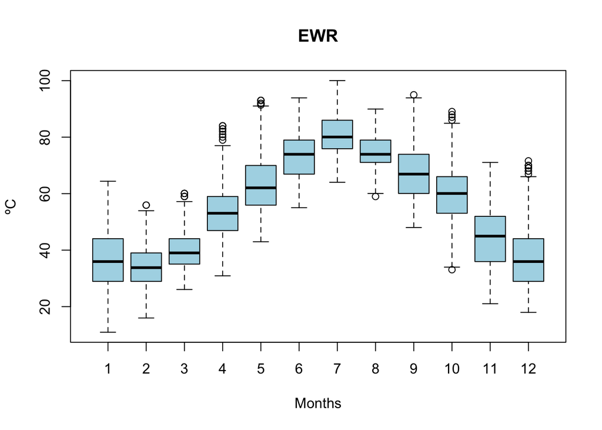

```
## [1] 55.54655 55.76261 54.47215
```

```r
EWR <- tiempo[tiempo$origin == "EWR",]
JFK <- tiempo[tiempo$origin == "JFK",]

plot_meteo <- function(data,columna,titulo,unidades)
  {
  dat <- data.frame(data)
  x <- dat[,columna]
   boxplot(x ~ dat$month, type ="l", ylab = unidades, xlab= "Months",col="lightblue", main = titulo)
 media <- c(mean(EWR$temp,na.rm=T),mean(LGA$temp,na.rm=T),mean(JFK$temp,na.rm=T))

 return(media)
 print(media)
}

plot_meteo(EWR,"temp","EWR","ºC")
```

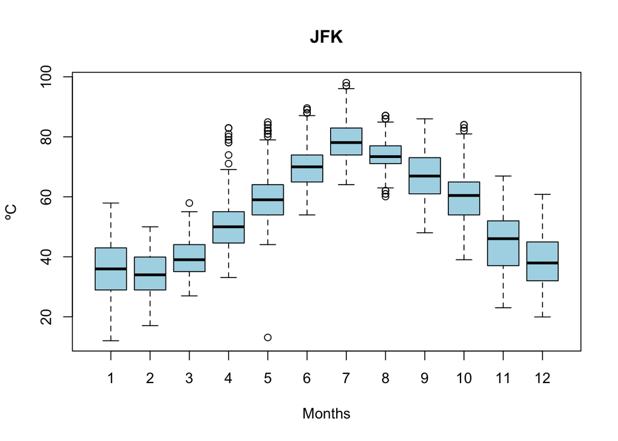

```
## [1] 55.54655 55.76261 54.47215
```

```r
plot_meteo(JFK,"temp","JFK","ºC")
```

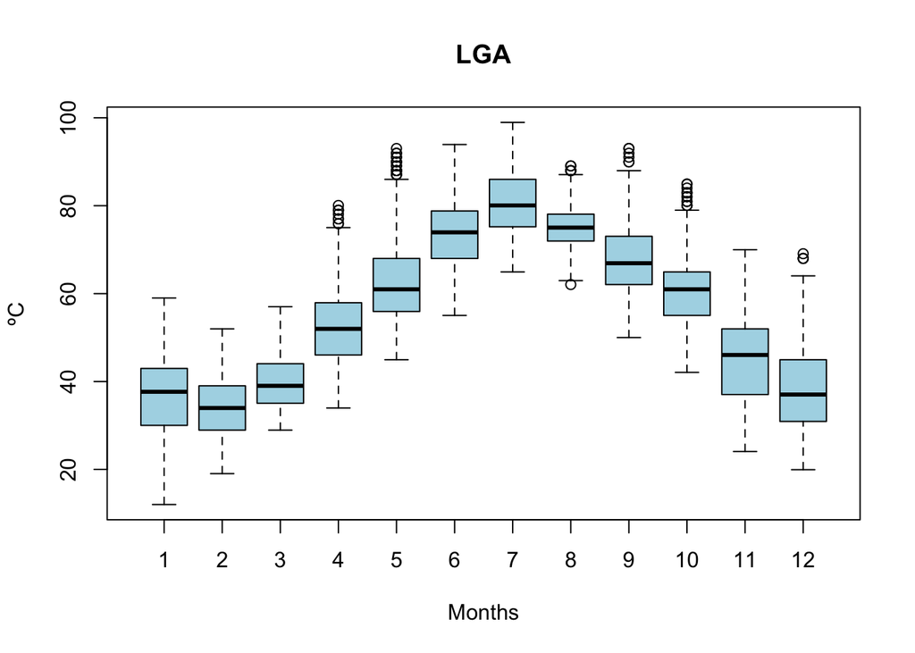

```
## [1] 55.54655 55.76261 54.47215
```

```r
plot_meteo(LGA,"temp","LGA","ºC")
```

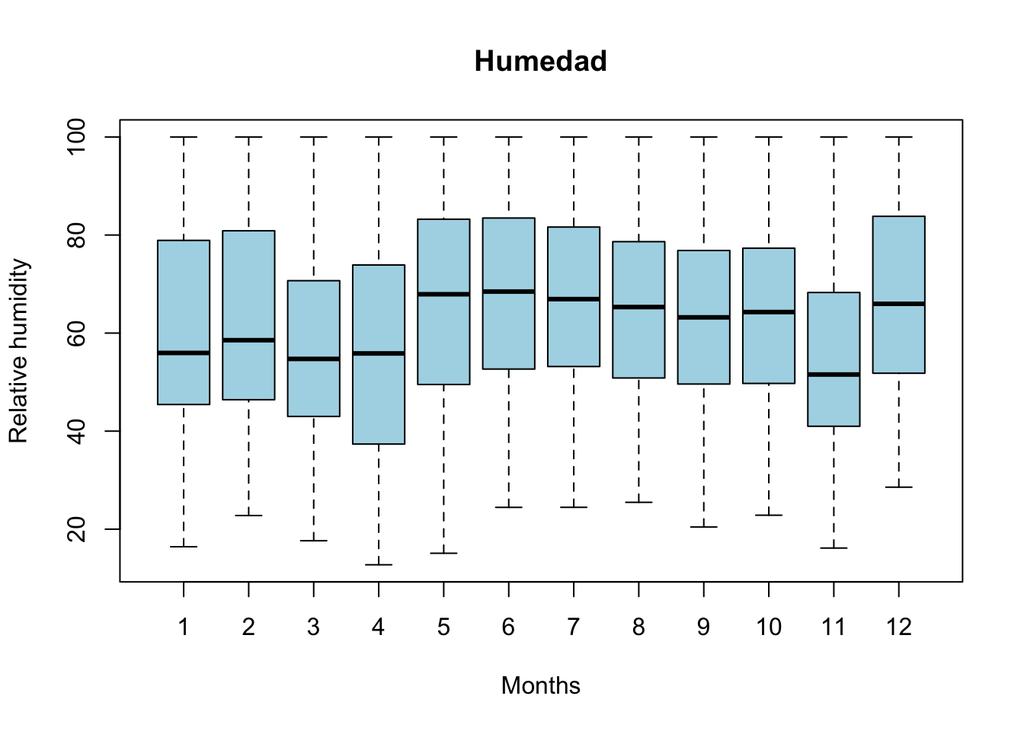

```
## [1] 55.54655 55.76261 54.47215
```

```r
plot_meteo(tiempo,"humid", "Humedad","Relative humidity")
```

#### 4. El día de tu cumpleaños:

##### a. Qué correlación tuvieron la temperatura y humedad en cada uno de los origin? Plotealo mediante puntos con ggplot.

```r
dia_cumple <- filter(tiempo, day == 4)
cumpleanos <- filter(dia_cumple, month == 2)
cumpleanosEWR <- filter(cumpleanos, origin=="EWR")
cumpleanosLGA <- filter(cumpleanos, origin=="LGA")
cumpleanosJFK <- filter(cumpleanos, origin=="JFK")

cor(cumpleanosEWR$temp,cumpleanosEWR$humid)
```

```
## [1] -0.7037327
```

```r
print(paste0("la correlación entre temperatura y humedad en el aeropuerto EWR el día de mi cumpleaños fue ", cor(cumpleanosEWR$temp,cumpleanosEWR$humid), " lo que indica que las dos variables están asociadas en sentido inverso"))
```

```
## [1] "la correlación entre temperatura y humedad en el aeropuerto EWR el día de mi cumpleaños fue -0.703732727048589 lo que indica que las dos variables están asociadas en sentido inverso"
```

```r
cor(cumpleanosLGA$temp,cumpleanosLGA$humid)
```

```
## [1] -0.4264978
```

```r
print(paste0("la correlación entre temperatura y humedad en el aeropuerto LGA el día de mi cumpleaños fue ",cor(cumpleanosLGA$temp,cumpleanosLGA$humid) , " lo que indica que las dos variables están asociadas en sentido inverso"))
```

```
## [1] "la correlación entre temperatura y humedad en el aeropuerto LGA el día de mi cumpleaños fue -0.42649779611934 lo que indica que las dos variables están asociadas en sentido inverso"
```

```r
cor(cumpleanosJFK$temp,cumpleanosJFK$humid)
```

```
## [1] -0.4397651
```

```r
print(paste0("la correlación entre temperatura y humedad en el aeropuerto JFK el día de mi cumpleaños fue ",cor(cumpleanosJFK$temp,cumpleanosJFK$humid), " lo que indica que las dos variables están asociadas en sentido inverso"))
```

```
## [1] "la correlación entre temperatura y humedad en el aeropuerto JFK el día de mi cumpleaños fue -0.439765073447183 lo que indica que las dos variables están asociadas en sentido inverso"
```

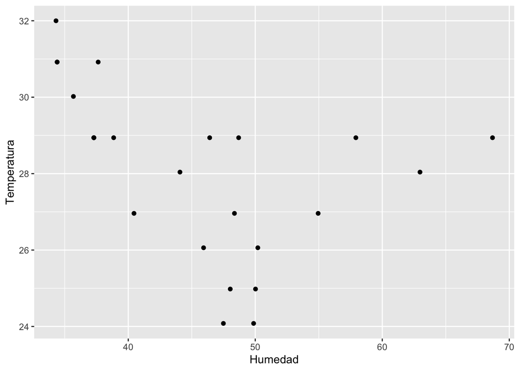

```r
 ggplot(data = cumpleanosJFK) +
  geom_point(mapping = aes(x = humid, y = temp)) + xlab("Humedad") + ylab("Temperatura")
```

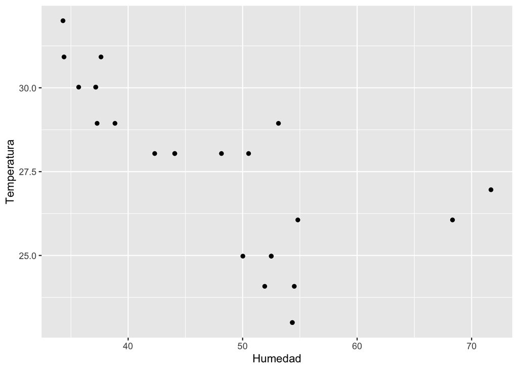

```r
ggplot(data = cumpleanosEWR) +
  geom_point(mapping = aes(x = humid, y = temp,)) + xlab("Humedad") + ylab("Temperatura")
```

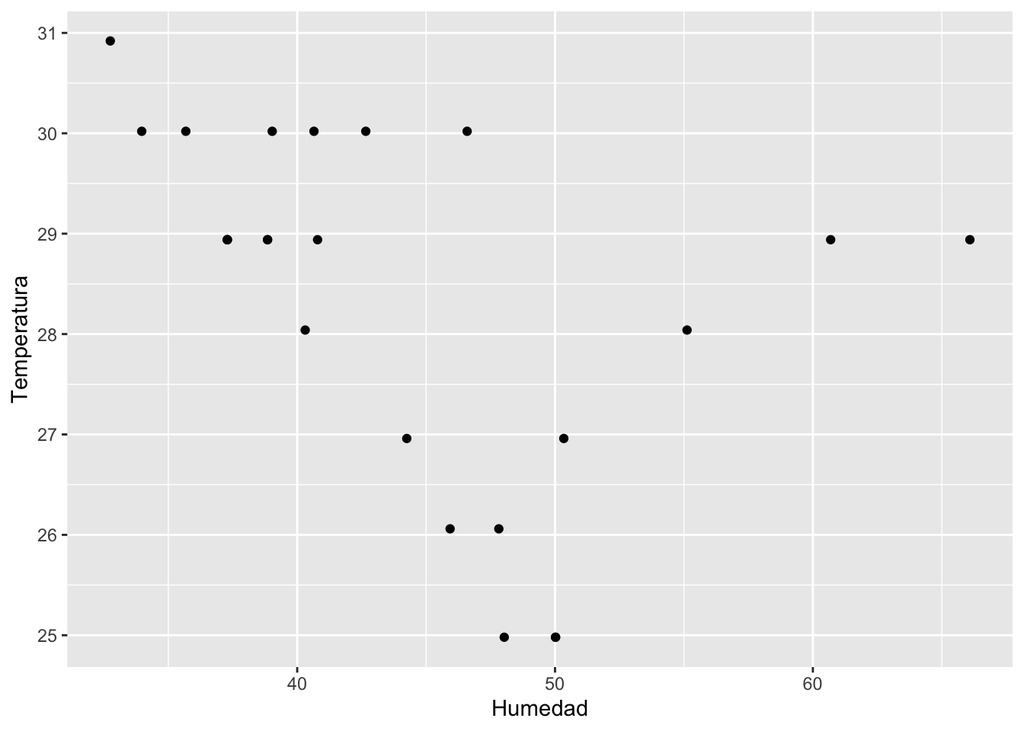

```r
 ggplot(data = cumpleanosLGA) +
  geom_point(mapping = aes(x = humid, y = temp)) + xlab("Humedad") + ylab("Temperatura")
```

##### b. Si comparas la temperatura en los origins JFK y LGA ¿son estadísticamente diferentes? ¿Qué p-valor consigues? Plotea los boxplots.

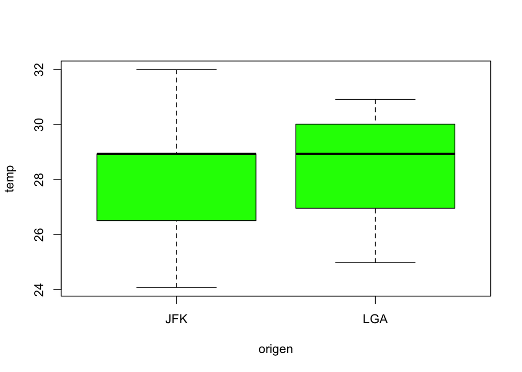

```r
cumpleanos_JFKyLGA <- filter(cumpleanos, origin=="JFK" | origin == "LGA")
boxplot(cumpleanos_JFKyLGA$temp ~ cumpleanos_JFKyLGA$origin, ylab = "temp", xlab = "origen", col = "green")
```

```r
t.test(cumpleanos_JFKyLGA$temp ~ cumpleanos_JFKyLGA$origin)
```

```
##
##  Welch Two Sample t-test
##
## data:  cumpleanos_JFKyLGA$temp by cumpleanos_JFKyLGA$origin
## t = -0.438, df = 44.208, p-value = 0.6635
## alternative hypothesis: true difference in means between group JFK and group LGA is not equal to 0
## 95 percent confidence interval:
##  -1.4281671  0.9181671
## sample estimates:
## mean in group JFK mean in group LGA
##           28.0625           28.3175
```

No hay diferencias estadisticamente significativas entre las temperaturas en los aeropuertos JFK y LGA el día de mi cumpleaños.

#### 6. Sube el examen a github y escribe a continuación tu url aquí.

https://github.com/cristinamgu/examen.git